# STATS503_HW3_Shenyi Tang

#### Question 1

**ISLP chapter 4, conceptual excercise #1**

**Using a little bit of algebra, prove that (4.2)** $$p(X)=\cfrac{e^{\beta_0+\beta_1 X}}{1+e^{\beta_0+\beta_1 X}}$$ **is equivalent to (4.3)** $$\cfrac{p(X)}{1-p(X)}=e^{\beta_0+\beta_1 X}$$ **In other words, the logistic function representation and logit representation for the logistic regression model are equivalent.**

Let $Z = e^{\beta_0+\beta_1X}, p(X) = \frac{Z}{1+Z}$

So we can get, $$ \begin{align*} \frac{1}{p(X)} &= \frac{1+Z}{Z} = \frac{1}{Z} + 1 \\ \frac{1}{p(X)} - 1 &= \frac{1}{Z} \\ Z &= \frac{1}{\frac{1}{p(X)} - 1} = \frac{1}{\frac{1-p(X)}{p(X)}} = \frac{p(X)}{1-p(X)} = e^{\beta_0+\beta_1X} \end{align*} $$

#### Question 2

**ISLP chapter 4, conceptual excercise #4**

**(a) Suppose that we have a set of observations, each with measurements on** $p=1$ **feature,** $X.$ **We assume that** $X$ **is uniformly (evenly) distributed on** $[0,1]$. **Associated with each observation is a response value. Suppose that Suppose that we wish to predict a test observation’s response using only observations that are within** $10\%$ **of the range of** $X$ **closest to that test observation. For instance, in order to predict the response for a test observation with** $X=6,$ **we use observations in the range** $[0.55,0.65].$ **On the average, what fraction of the available observations will we use to make the prediction?**

$10\%$

**(b) Now suppose that we have a set of observations, each with measurements on** $p = 2$ **features,** $X_1$ **and** $X_2$. **We assume that** ($X_1$, $X_2$) **are uniformly distributed on** $[0, 1]\times[0, 1]$. **We wish to predict a test observation’s response using only observations that are within** $10\%$ **of the range of** $X_1$ **and within** $10\%$ **of the range of** $X_2$ **closest to that test observation. For instance, in order to predict the response for a test observation with** $X1 = 0.6$ **and** $X2 = 0.35$ **, we will use observations in the range** $[0.55, 0.65]$ **for X1 and in the range** $[0.3, 0.4]$ **for** $X_2$ **. On average, what fraction of the available observations will we use to make the prediction?**

$1\%$

**(c) Now suppose that we have a set of observations on $p = 100$ features. Again the observations are uniformly distributed on each feature, and again each feature ranges in value from 0 to 1. We wish to predict a test observation’s response using observations within the $10\%$ of each feature’s range that is closest to that test observation. What fraction of the available observations will we use to make the prediction?**

$\cfrac{1}{10^{100}}$

**(d) Using your answers to parts (a)–(c), argue that a drawback of KNN when p is large is that there are very few training observations “near” any given test observation.**

As $p$ gets larger, the fraction of the available observations will be $\cfrac{1}{10^p}$, tending to be zero.

**(e) Now suppose that we wish to make a prediction for a test observation by creating a $p-$dimensional hypercube centered around the test observation that contains, on average, $10\%$ of the training observations. For $p = 1, 2,$ and $100$, what is the length of each side of the hypercube? Comment on your answer.**

For $p=1$, the length of the side is ${0.1}$

For $p=2$, the length of the side is $\sqrt{0.1}$

For $p=100$, the length of the side is $\sqrt[100]{0.1}$

#### Question 3

**ISLP chapter 4, conceptual exercise #9**

**This problem has to do with odds**

**(a) On average, what fraction of people with an odds of $0.37$ of defaulting on their credit card payment will in fact default?**

$\cfrac{p(x)}{1-p(x)}=0.37 \Rightarrow p(x)\approx 0.27$

**(b) Suppose that an individual has a 16 % chance of defaulting on her credit card payment. What are the odds that she will default?**

$p(x)=0.16\Rightarrow \cfrac{p(x)}{1-p(x)}\approx 0.19$

#### Question 4

**ISLP chapter 4, conceptual excercise #12, parts a, b, and c**

Suppose that you wish to classify an observation $X \in \mathbb{R}$ into apples and oranges. You fit a logistic regression model and find that $$\widehat{Pr}(Y=\text{orange}|X=x)=\cfrac{\text{exp}(\hat{\beta_0}+\hat{\beta_1}x)}{1+\text{exp}(\hat{\beta_0}+\hat{\beta_1}x)}$$ Your friend fits a logistic regression model to the same data using $softmax$ formulation in $(4.13)$, and finds that $$ \widehat{\text{Pr}}(Y = \text{orange}|X = x) = \frac{\exp(\hat{\alpha}_{\text{orange}0} + \hat{\alpha}_{\text{orange}1}x)}{\exp(\hat{\alpha}_{\text{orange}0} + \hat{\alpha}_{\text{orange}1}x) + \exp(\hat{\alpha}_{\text{apple}0} + \hat{\alpha}_{\text{apple}1}x)}. $$

**(a) What is the log odds of $\text{orange}$ versus $\text{apple}$ in your model**

$$ \begin{gathered} \because log\ odds=\text{ln}(\cfrac{p(x)}{1-p(x)}) \\ \therefore log\ odds_{\text{orange vs. apple}} = \hat{\beta}_0+\hat{\beta}_1x \end{gathered} $$

**(b) What is the log odds of $\text{orange}$ versus $\text{apple}$ in your friend's model**

$$ \begin{gathered} \because log\ odds=\text{ln}(\cfrac{p(x)}{1-p(x)}) \\ \therefore log\ odds_{\text{orange vs. apple}} = (\hat{\alpha}_{\text{orange}0} + \hat{\alpha}_{\text{orange}1}x)-(\hat{\alpha}_{\text{apple}0} + \hat{\alpha}_{\text{apple}1}x) \end{gathered} $$

**(c) Suppose that in your model, $\hat{\beta}_0=2$ and $\hat{\beta}_1=-1$. What are coefficients estimated in your friend's model? Be as specific as possible.**

In my model, $log\ odds=2-x$.

Therefore in my friend's model, $\hat{\alpha}_{\text{orange}0}-\hat{\alpha}_{\text{apple}0}=2,\ \hat{\alpha}_{\text{orange}1}-\hat{\alpha}_{\text{apple}1}=-1$

Therefore, $\hat{\alpha}_{\text{orange}0}=2,\ \hat{\alpha}_{\text{orange}1}=-1,\ \hat{\alpha}_{\text{apple}0}=0, \hat{\alpha}_{\text{apple}1}=0$

#### Question 5

**Suppose we fit logistic regression to predict the probability that a STATS 503 student gets an A in the class, from two variables. The variables are average hours of study per week $(X_1)$ adn GPA in other statistics courses taken $(X_2)$. The model estimates $\beta_0=-4, \beta_1=0.05, \beta_2=1$.**

**(a) Predict the probability of getting an A for a student who studies 5 hours a week and has a GPA of 3.5 in other statistics courses.**

$$ \begin{gathered} \widehat{p(x)}=\cfrac{exp(\hat{\beta}_0+\hat{\beta}_1X_1+\hat{\beta}_2X_2)}{1+exp(\hat{\beta}_0+\hat{\beta}_1X_1+\hat{\beta}_2X_2)} \\[1em] \because X_1=5,\ X_2=3.5 \\[1em] \therefore \widehat{p(x)}=\cfrac{e^{-0.25}}{1+e^{-0.25}}\approx 0.4378 \end{gathered} $$

**(b) What are the odds that this student will get an A?**

**(c) How many hours does this student need to study for the model to predict a $50\%$ change of getting an A.**

$$ \begin{gathered} 0.5 = \cfrac{exp(-4+\hat{\beta}_1X_1+3.5)}{1+exp(-4+\hat{\beta}_1X_1+3.5)} \\[1em] X_1=10 \end{gathered} $$

#### Question 6

**Download the `college_train` and `college_test` datasets from Canvas and load them as dataframes. Fit a `sklearn.linear_model.LogisticRegression` model to predict the Private variable from all other variables except for Name, using the `college_train` dataset. Let $\hat{p}(y|x)$ denote the fitted model.**

```python
import numpy as np
import pandas as pd
from sklearn.linear_model import LogisticRegression
from sklearn.preprocessing import StandardScaler

college_train = pd.read_csv("college_train.csv", sep=',')

college_test = pd.read_csv("college_test.csv", sep=',')


college_train["Private"] = college_train["Private"].map({"Yes": 1, "No": 0})
college_test["Private"] = college_test["Private"].map({"Yes": 1, "No": 0})
X_train = college_train.drop(columns=["Private", "Name"])
y_train = college_train["Private"]
X_test = college_test.drop(columns=["Private", "Name"])
y_test = college_test["Private"]

print(college_train.head())
print(college_test.head())
```

```
                                   Name  Private   Apps  Accept  Enroll  \
0   Northwest Missouri State University        0   2729    2535    1257
1              Ohio Wesleyan University        1   2190    1700     458
2                      Westmont College        0    950     713     351
3                 Carson-Newman College        1   1096     951     464
4  Arizona State University Main campus        0  12809   10308    3761

   Top10perc  Top25perc  F.Undergrad  P.Undergrad  Outstate  Room.Board  \
0          8         29         4787          472      3735        3136
1         36         65         1780           48     16732        5650
2         42         72         1276            9     14320        5304
3         27         62         1776          239      8150        3150
4         24         49        22593         7585      7434        4850

   Books  Personal  PhD  Terminal  S.F.Ratio  perc.alumni  Expend  Grad.Rate
```

[output cut: 25 more lines]

**(a) For each sample in the `college_test` dataset, use the fit model to predict the probability that `Private` is `Yes` and use the fit model to predict the probability that `Private` is `No`. Use these probabilities to calculate the negative log likelihood of the testing datase for the model:** $$-\sum_{i=1}^{n}\text{log}\hat{p}(y_i|x_i)$$ **where $n$ is the number of samples in `college_test` and each $(x_i,y_i)$ pair is a sample from that dataset.**

```python
from sklearn.metrics import log_loss

scaler = StandardScaler()
X_train = scaler.fit_transform(X_train)
X_test = scaler.transform(X_test)

# model
model = LogisticRegression()
model.fit(X_train, y_train)

# first column: p(no|X)
# second column: p(yes|X)
y_prob = model.predict_proba(X_test)

# log_probs = []

# for i in range(len(y_test)):
#     # to pick out the estimated prob responding to the actual category for each test sample
#     prob = y_prob[i][y_test]
#     log_probs.append(np.log(prob))

negative_log_likelihood = log_loss(y_test, y_prob) * len(y_test)

print(f"Negative log likelihood: {negative_log_likelihood}")
```

```
Negative log likelihood: 16.719303439208065
```

**(b) Now use $\hat{p}$ to create a hard classifier, also known as a decision rule. Specifically, consider the rule** $$ \hat{y}(x)=\begin{cases} \text{Yes}& \text{if }\hat{p}(\text{Yes}|x)>0.5 \\[1em] \text{No}& \text{otherwise.} \end{cases} $$ **Using the test data, compute the false positive rate (FPR), true positive rate (TPR), false negative rate (FNR), and true negative rate (TNR) made by this decision rule.**

```python
from sklearn.metrics import confusion_matrix

y_pred = np.where(y_prob[:, 1] > 0.5, 1, 0)

cnf_matrix = confusion_matrix(y_test, y_pred)
print("Confusion Matrix:")
print(cnf)

FP = cnf_matrix[0,1] # it is "negative" (class 0) but we predict +1
FN = cnf_matrix[1,0]
TP = cnf_matrix[1,1]
TN = cnf_matrix[0,0]

FP = FP.astype(float)
FN = FN.astype(float)
TP = TP.astype(float)
TN = TN.astype(float)

metrics=pd.Series(dict(
    # Fall out or false positive rate
    FPR = FP/(FP+TN),
    # Sensitivity, hit rate, recall, or true positive rate
    TPR = TP/(TP+FN),
    # False negative rate
    FNR = FN/(TP+FN),
     # Specificity or true negative rate
    TNR = TN/(TN+FP)
))
print(metrics)
```

[output not shown]

**(c) We will now use $\hat{p}$ to create a different classifier.** $$ \hat{y}(x)=\begin{cases} \text{Yes}& \text{if }\hat{p}(\text{Yes}|x)>0.9 \\[1em] \text{No}& \text{otherwise.} \end{cases} $$ **Using the test data, compute the FPR, TPR, FNR, and TNR for this new decision rule.**

```python
from sklearn.metrics import confusion_matrix

y_pred_new = np.where(y_prob[:, 1] > 0.9, 1, 0)

cnf_matrix_new = confusion_matrix(y_test, y_pred_new)
print("Confusion Matrix:")
print(cnf_matrix_new)

FP_new = cnf_matrix_new[0,1] # it is "negative" (class 0) but we predict +1
FN_new = cnf_matrix_new[1,0]
TP_new = cnf_matrix_new[1,1]
TN_new = cnf_matrix_new[0,0]

FP_new = FP_new.astype(float)
FN_new = FN_new.astype(float)
TP_new = TP_new.astype(float)
TN_new = TN_new.astype(float)

metrics_new=pd.Series(dict(
    # Fall out or false positive rate
    FPR = FP_new/(FP_new+TN_new),
    # Sensitivity, hit rate, recall, or true positive rate
    TPR = TP_new/(TP_new+FN_new),
    # False negative rate
    FNR = FN_new/(TP_new+FN_new),
     # Specificity or true negative rate
    TNR = TN_new/(TN_new+FP_new)
))
print(metrics_new)
```

```
Confusion Matrix:
[[32  1]
 [22 72]]
FPR    0.030303
TPR    0.765957
FNR    0.234043
TNR    0.969697
dtype: float64
```

**(d) We will now use $\hat{p}$ to create a family of different hard classifiers.**

$$\hat{y}_t(x) = \begin{cases} \text{Yes} & \text{if }\hat{p}(\text{Yes}|x) > t \\ \text{No} & \text{otherwise.} \end{cases}$$

**Using the test data, for each value of $t \in \{0.0, 1/100, 2/100, \ldots, 99/100, 1.0\}$, compute the FPR and TPR of the decision rule $\hat{y}_t$. Plot your results as an ROC curve.**

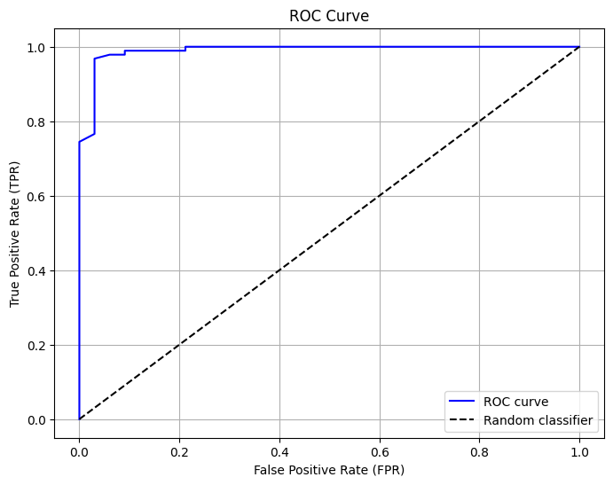

```python
import matplotlib.pyplot as plt
thresholds = np.linspace(0, 1, 101)

fprs = []
tprs = []

for t in thresholds:
    y_pred = np.where(y_prob[:, 1] > t, 1, 0)

    tn = sum((y_test == 0) & (y_pred == 0))
    fp = sum((y_test == 0) & (y_pred == 1))
    fn = sum((y_test == 1) & (y_pred == 0))
    tp = sum((y_test == 1) & (y_pred == 1))

    fpr = fp / (fp + tn) if (fp + tn) > 0 else 0
    tpr = tp / (tp + fn) if (tp + fn) > 0 else 0

    fprs.append(fpr)
    tprs.append(tpr)

plt.figure(figsize=(8, 6))
plt.plot(fprs, tprs, 'b-', label='ROC curve')
plt.plot([0, 1], [0, 1], 'k--', label='Random classifier')
plt.xlabel('False Positive Rate (FPR)')
plt.ylabel('True Positive Rate (TPR)')
plt.title('ROC Curve')
plt.legend()
plt.grid(True)
plt.show()
```

**(e) Use $\hat{p}$, the test data, and `sklearn.metrics.roc_auc_score` to compute the area under your ROC curve. The first argument should be the true labels from the testing dataset. The second argument should be the probability that `Private` is `Yes`, as predicted by your model.**

```python
from sklearn.metrics import roc_auc_score

print(f"The AUC: {roc_auc_score(y_test, y_prob[:, 1])}")
```

```
The AUC: 0.9903288201160542
```